# Liver Tumor Segmentation with Deep Learning Architectures

## Name: Rahul Pandya

Student Id: 2121685

# 1. Importing Libraries

```python
import numpy as np
import pandas as pd
import os
import glob
import cv2
import imageio

import numpy as np
import pandas as pd
import nibabel as nib
import matplotlib.pyplot as plt

from tqdm.notebook import tqdm
from ipywidgets import *
from PIL import Image
from matplotlib.pyplot import figure

from fastai.basics import *
from fastai.vision.all import *
from fastai.data.transforms import *
```

The above code imports a comprehensive set of libraries to support data manipulation, medical imaging analysis, image processing, visualization, and machine learning tasks. These libraries are pivotal for handling healthcare datasets, especially in tasks like medical image segmentation, classification, and analysis. The following descriptions highlight the purpose and use cases of each library:

numpy: A fundamental library for numerical computations, it facilitates efficient handling of multi-dimensional arrays and matrices, which are integral in deep learning and image processing workflows.

pandas: Ideal for data manipulation and analysis, it is used to manage structured datasets such as patient demographics or clinical metadata associated with medical images.

os and glob: These libraries assist in file and directory operations, particularly useful for navigating through large datasets stored in hierarchical structures.

cv2: OpenCV is a powerful image processing library employed for operations like resizing, cropping, or advanced augmentation techniques to enhance image datasets for better model performance.

imageio: A versatile library for reading and writing images in various formats, including those commonly used in medical imaging workflows.

nibabel: Specifically designed for medical imaging, it provides tools to load and manipulate NIfTI and other volumetric image formats, essential for analyzing MRI and CT scans.

matplotlib.pyplot: A robust visualization tool, it is used for creating detailed plots and displaying image slices, aiding in the qualitative evaluation of medical imaging tasks.

tqdm.notebook: This module integrates progress bars into Jupyter Notebooks, making it easier to track the status of data preprocessing or model training pipelines.

ipywidgets: Enables the creation of interactive controls and visualizations in notebooks, useful for dynamic exploration of datasets or hyperparameter tuning.

PIL.Image: Pillow allows for versatile image manipulation, such as resizing or format conversion, crucial for preprocessing raw medical images.

fastai Libraries: FastAI provides high-level abstractions for deep learning, focusing on simplifying tasks like data augmentation, training, and model deployment, particularly in computer vision tasks like tumor segmentation.

These libraries together form a robust toolkit for addressing challenges in medical imaging and machine learning projects, streamlining workflows from data preparation to model deployment.

# 2. Data Preparation

Here, we create a metadata file cataloging all NIfTI (.nii) files from specified directories for liver tumor segmentation. Using os.walk(), it collects file paths and names, organizes them into a pandas DataFrame, and sorts them by filename for consistency. The resulting metadata is essential for pairing volume and segmentation files, automating data loading, and ensuring reproducibility in preprocessing pipelines.

```python
# Create a meta file for nii files processing

file_list = []
for dirname, _, filenames in os.walk('../input/liver-tumor-segmentation'):
    for filename in filenames:
        file_list.append((dirname, filename))

for dirname, _, filenames in os.walk('../input/liver-tumor-segmentation-part-2'):
    for filename in filenames:
        file_list.append((dirname, filename))

df_files = pd.DataFrame(file_list, columns =['dirname', 'filename'])
df_files.sort_values(by=['filename'], ascending=True)
```

|  | dirname | filename |
| --- | --- | --- |
| 89 | ../input/liver-tumor-segmentation/segmentations | segmentation-0.nii |
| 81 | ../input/liver-tumor-segmentation/segmentations | segmentation-1.nii |
| 142 | ../input/liver-tumor-segmentation/segmentations | segmentation-10.nii |
| 31 | ../input/liver-tumor-segmentation/segmentations | segmentation-100.nii |
| 45 | ../input/liver-tumor-segmentation/segmentations | segmentation-101.nii |
| ... | ... | ... |
| 166 | ../input/liver-tumor-segmentation/volume_pt5 | volume-50.nii |
| 27 | ../input/liver-tumor-segmentation/volume_pt1 | volume-6.nii |
| 30 | ../input/liver-tumor-segmentation/volume_pt1 | volume-7.nii |
| 21 | ../input/liver-tumor-segmentation/volume_pt1 | volume-8.nii |
| 22 | ../input/liver-tumor-segmentation/volume_pt1 | volume-9.nii |

182 rows × 2 columns

```python
# Map CT scan and label


df_files["mask_dirname"]  = ""
df_files["mask_filename"] = ""

for i in range(131):
    ct = f"volume-{i}.nii"
    mask = f"segmentation-{i}.nii"

    df_files.loc[df_files['filename'] == ct, 'mask_filename'] = mask
    df_files.loc[df_files['filename'] == ct, 'mask_dirname'] = "../input/liver-tumor-segmentation/segmentations"

# drop segment rows
df_files = df_files[df_files.mask_filename != ''].sort_values(by=['filename']).reset_index(drop=True)

df_files
```

|  | dirname | filename | mask_dirname | mask_filename |
| --- | --- | --- | --- | --- |
| 0 | ../input/liver-tumor-segmentation/volume_pt1 | volume-0.nii | ../input/liver-tumor-segmentation/segmentations | segmentation-0.nii |
| 1 | ../input/liver-tumor-segmentation/volume_pt1 | volume-1.nii | ../input/liver-tumor-segmentation/segmentations | segmentation-1.nii |
| 2 | ../input/liver-tumor-segmentation/volume_pt1 | volume-10.nii | ../input/liver-tumor-segmentation/segmentations | segmentation-10.nii |
| 3 | ../input/liver-tumor-segmentation/volume_pt2 | volume-11.nii | ../input/liver-tumor-segmentation/segmentations | segmentation-11.nii |
| 4 | ../input/liver-tumor-segmentation/volume_pt2 | volume-12.nii | ../input/liver-tumor-segmentation/segmentations | segmentation-12.nii |
| 5 | ../input/liver-tumor-segmentation/volume_pt2 | volume-13.nii | ../input/liver-tumor-segmentation/segmentations | segmentation-13.nii |
| 6 | ../input/liver-tumor-segmentation/volume_pt2 | volume-14.nii | ../input/liver-tumor-segmentation/segmentations | segmentation-14.nii |
| 7 | ../input/liver-tumor-segmentation/volume_pt2 | volume-15.nii | ../input/liver-tumor-segmentation/segmentations | segmentation-15.nii |
| 8 | ../input/liver-tumor-segmentation/volume_pt2 | volume-16.nii | ../input/liver-tumor-segmentation/segmentations | segmentation-16.nii |
| 9 | ../input/liver-tumor-segmentation/volume_pt2 | volume-17.nii | ../input/liver-tumor-segmentation/segmentations | segmentation-17.nii |
| 10 | ../input/liver-tumor-segmentation/volume_pt2 | volume-18.nii | ../input/liver-tumor-segmentation/segmentations | segmentation-18.nii |
| 11 | ../input/liver-tumor-segmentation/volume_pt2 | volume-19.nii | ../input/liver-tumor-segmentation/segmentations | segmentation-19.nii |
| 12 | ../input/liver-tumor-segmentation/volume_pt1 | volume-2.nii | ../input/liver-tumor-segmentation/segmentations | segmentation-2.nii |
| 13 | ../input/liver-tumor-segmentation/volume_pt2 | volume-20.nii | ../input/liver-tumor-segmentation/segmentations | segmentation-20.nii |
| 14 | ../input/liver-tumor-segmentation/volume_pt3 | volume-21.nii | ../input/liver-tumor-segmentation/segmentations | segmentation-21.nii |
| 15 | ../input/liver-tumor-segmentation/volume_pt3 | volume-22.nii | ../input/liver-tumor-segmentation/segmentations | segmentation-22.nii |
| 16 | ../input/liver-tumor-segmentation/volume_pt3 | volume-23.nii | ../input/liver-tumor-segmentation/segmentations | segmentation-23.nii |
| 17 | ../input/liver-tumor-segmentation/volume_pt3 | volume-24.nii | ../input/liver-tumor-segmentation/segmentations | segmentation-24.nii |
| 18 | ../input/liver-tumor-segmentation/volume_pt3 | volume-25.nii | ../input/liver-tumor-segmentation/segmentations | segmentation-25.nii |
| 19 | ../input/liver-tumor-segmentation/volume_pt3 | volume-26.nii | ../input/liver-tumor-segmentation/segmentations | segmentation-26.nii |
| 20 | ../input/liver-tumor-segmentation/volume_pt3 | volume-27.nii | ../input/liver-tumor-segmentation/segmentations | segmentation-27.nii |
| 21 | ../input/liver-tumor-segmentation/volume_pt3 | volume-28.nii | ../input/liver-tumor-segmentation/segmentations | segmentation-28.nii |
| 22 | ../input/liver-tumor-segmentation/volume_pt3 | volume-29.nii | ../input/liver-tumor-segmentation/segmentations | segmentation-29.nii |
| 23 | ../input/liver-tumor-segmentation/volume_pt1 | volume-3.nii | ../input/liver-tumor-segmentation/segmentations | segmentation-3.nii |
| 24 | ../input/liver-tumor-segmentation/volume_pt3 | volume-30.nii | ../input/liver-tumor-segmentation/segmentations | segmentation-30.nii |
| 25 | ../input/liver-tumor-segmentation/volume_pt4 | volume-31.nii | ../input/liver-tumor-segmentation/segmentations | segmentation-31.nii |
| 26 | ../input/liver-tumor-segmentation/volume_pt4 | volume-32.nii | ../input/liver-tumor-segmentation/segmentations | segmentation-32.nii |
| 27 | ../input/liver-tumor-segmentation/volume_pt4 | volume-33.nii | ../input/liver-tumor-segmentation/segmentations | segmentation-33.nii |
| 28 | ../input/liver-tumor-segmentation/volume_pt4 | volume-34.nii | ../input/liver-tumor-segmentation/segmentations | segmentation-34.nii |
| 29 | ../input/liver-tumor-segmentation/volume_pt4 | volume-35.nii | ../input/liver-tumor-segmentation/segmentations | segmentation-35.nii |
| 30 | ../input/liver-tumor-segmentation/volume_pt4 | volume-36.nii | ../input/liver-tumor-segmentation/segmentations | segmentation-36.nii |
| 31 | ../input/liver-tumor-segmentation/volume_pt4 | volume-37.nii | ../input/liver-tumor-segmentation/segmentations | segmentation-37.nii |
| 32 | ../input/liver-tumor-segmentation/volume_pt4 | volume-38.nii | ../input/liver-tumor-segmentation/segmentations | segmentation-38.nii |
| 33 | ../input/liver-tumor-segmentation/volume_pt4 | volume-39.nii | ../input/liver-tumor-segmentation/segmentations | segmentation-39.nii |
| 34 | ../input/liver-tumor-segmentation/volume_pt1 | volume-4.nii | ../input/liver-tumor-segmentation/segmentations | segmentation-4.nii |
| 35 | ../input/liver-tumor-segmentation/volume_pt4 | volume-40.nii | ../input/liver-tumor-segmentation/segmentations | segmentation-40.nii |
| 36 | ../input/liver-tumor-segmentation/volume_pt5 | volume-41.nii | ../input/liver-tumor-segmentation/segmentations | segmentation-41.nii |
| 37 | ../input/liver-tumor-segmentation/volume_pt5 | volume-42.nii | ../input/liver-tumor-segmentation/segmentations | segmentation-42.nii |
| 38 | ../input/liver-tumor-segmentation/volume_pt5 | volume-43.nii | ../input/liver-tumor-segmentation/segmentations | segmentation-43.nii |
| 39 | ../input/liver-tumor-segmentation/volume_pt5 | volume-44.nii | ../input/liver-tumor-segmentation/segmentations | segmentation-44.nii |
| 40 | ../input/liver-tumor-segmentation/volume_pt5 | volume-45.nii | ../input/liver-tumor-segmentation/segmentations | segmentation-45.nii |
| 41 | ../input/liver-tumor-segmentation/volume_pt5 | volume-46.nii | ../input/liver-tumor-segmentation/segmentations | segmentation-46.nii |
| 42 | ../input/liver-tumor-segmentation/volume_pt5 | volume-47.nii | ../input/liver-tumor-segmentation/segmentations | segmentation-47.nii |
| 43 | ../input/liver-tumor-segmentation/volume_pt5 | volume-48.nii | ../input/liver-tumor-segmentation/segmentations | segmentation-48.nii |
| 44 | ../input/liver-tumor-segmentation/volume_pt5 | volume-49.nii | ../input/liver-tumor-segmentation/segmentations | segmentation-49.nii |
| 45 | ../input/liver-tumor-segmentation/volume_pt1 | volume-5.nii | ../input/liver-tumor-segmentation/segmentations | segmentation-5.nii |
| 46 | ../input/liver-tumor-segmentation/volume_pt5 | volume-50.nii | ../input/liver-tumor-segmentation/segmentations | segmentation-50.nii |
| 47 | ../input/liver-tumor-segmentation/volume_pt1 | volume-6.nii | ../input/liver-tumor-segmentation/segmentations | segmentation-6.nii |
| 48 | ../input/liver-tumor-segmentation/volume_pt1 | volume-7.nii | ../input/liver-tumor-segmentation/segmentations | segmentation-7.nii |
| 49 | ../input/liver-tumor-segmentation/volume_pt1 | volume-8.nii | ../input/liver-tumor-segmentation/segmentations | segmentation-8.nii |
| 50 | ../input/liver-tumor-segmentation/volume_pt1 | volume-9.nii | ../input/liver-tumor-segmentation/segmentations | segmentation-9.nii |

# 3. Data Preprocessing

Here, this step preprocess NIfTI (`.nii`) files for liver tumor segmentation by defining functions and methods to handle, normalize, and visualize medical imaging data. The `read_nii` function reads and rotates `.nii` files into 3D arrays.

DICOM windowing is applied to enhance contrast and focus on specific intensity ranges, such as liver structures. Sample data is loaded and visualized to validate preprocessing, ensuring readiness for machine learning workflows.

```python
def read_nii(filepath):
    '''
    Reads .nii file and returns pixel array
    '''
    ct_scan = nib.load(filepath)
    array   = ct_scan.get_fdata()
    array   = np.rot90(np.array(array))
    return(array)
```

```python
# Read sample

sample = 40
sample_ct = read_nii(df_files.loc[sample,'dirname']+"/"+df_files.loc[sample,'filename'])
sample_mask = read_nii(df_files.loc[sample,'mask_dirname']+"/"+df_files.loc[sample,'mask_filename'])

print(f'CT Shape:   {sample_ct.shape}\nMask Shape: {sample_mask.shape}')
```

```
CT Shape:   (512, 512, 74)
Mask Shape: (512, 512, 74)
```

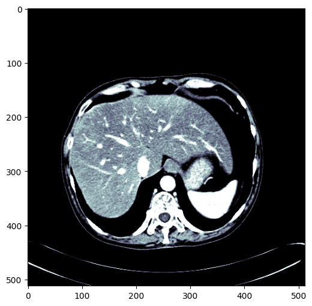

```python
# Preprocess the nii file
# Source https://docs.fast.ai/medical.imaging

dicom_windows = types.SimpleNamespace(
    brain=(80,40),
    subdural=(254,100),
    stroke=(8,32),
    brain_bone=(2800,600),
    brain_soft=(375,40),
    lungs=(1500,-600),
    mediastinum=(350,50),
    abdomen_soft=(400,50),
    liver=(150,30),
    spine_soft=(250,50),
    spine_bone=(1800,400),
    custom = (200,60)
)

@patch
def windowed(self:Tensor, w, l):
    px = self.clone()
    px_min = l - w//2
    px_max = l + w//2
    px[px<px_min] = px_min
    px[px>px_max] = px_max
    return (px-px_min) / (px_max-px_min)

figure(figsize=(8, 6), dpi=100)

plt.imshow(tensor(sample_ct[..., 55].astype(np.float32)).windowed(*dicom_windows.liver), cmap=plt.cm.bone);
```

# Data Visualization

## Display Sample Images

plot_sample Function: Displays a slice of a CT scan, its windowed version, the segmentation mask, and a combined overlay for visual analysis.

```python
def plot_sample(array_list, color_map = 'nipy_spectral'):
    '''
    Plots and a slice with all available annotations
    '''
    fig = plt.figure(figsize=(20,16), dpi=100)

    plt.subplot(1,4,1)
    plt.imshow(array_list[0], cmap='bone')
    plt.title('Original Image')
    plt.axis('off')

    plt.subplot(1,4,2)
    plt.imshow(tensor(array_list[0].astype(np.float32)).windowed(*dicom_windows.liver), cmap='bone');
    plt.title('Windowed Image')
    plt.axis('off')

    plt.subplot(1,4,3)
    plt.imshow(array_list[1], alpha=0.5, cmap=color_map)
    plt.title('Mask')
    plt.axis('off')

    plt.subplot(1,4,4)
    plt.imshow(array_list[0], cmap='bone')
    plt.imshow(array_list[1], alpha=0.5, cmap=color_map)
    plt.title('Liver & Mask')
    plt.axis('off')

    plt.show()
```

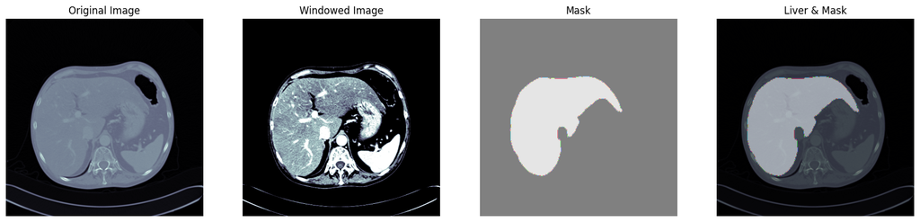

```python
sample = 45

sample_slice = tensor(sample_ct[...,sample].astype(np.float32))

plot_sample([sample_ct[..., sample],
             sample_mask[..., sample]])
```

***DICOM Windowing:*** Adjusts image intensity using predefined window-level settings for better focus on anatomical features.

***Histogram Scaling:*** Normalizes pixel values to a standard range (0-1).

***Multi-Channel Conversion:***

Converts images to a format suitable for saving as JPEG, with multiple channels for enhanced processing.

Use Case: Prepares and standardizes CT scan data for model input.

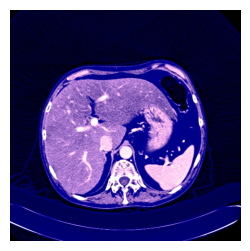

```python
# Preprocessing functions
class TensorCTScan(TensorImageBW): _show_args = {'cmap':'bone'} #a subclass of a PyTorch Tensor designed to handle black-and-white images.

@patch
def freqhist_bins(self:Tensor, n_bins=100):
    "A function to split the range of pixel values into groups, such that each group has around the same number of pixels"
    imsd = self.view(-1).sort()[0]
    t = torch.cat([tensor([0.001]),
                   torch.arange(n_bins).float()/n_bins+(1/2/n_bins),
                   tensor([0.999])])
    t = (len(imsd)*t).long()
    return imsd[t].unique()

@patch
def hist_scaled(self:Tensor, brks=None):
    "Scales a tensor using `freqhist_bins` to values between 0 and 1"
    if self.device.type=='cuda': return self.hist_scaled_pt(brks)
    if brks is None: brks = self.freqhist_bins()
    ys = np.linspace(0., 1., len(brks))
    x = self.numpy().flatten()
    x = np.interp(x, brks.numpy(), ys)
    return tensor(x).reshape(self.shape).clamp(0.,1.)


@patch
def to_nchan(x:Tensor, wins, bins=None):
    res = [x.windowed(*win) for win in wins]
    if not isinstance(bins,int) or bins!=0: res.append(x.hist_scaled(bins).clamp(0,1))
    dim = [0,1][x.dim()==3]
    return TensorCTScan(torch.stack(res, dim=dim))

@patch
def save_jpg(x:(Tensor), path, wins, bins=None, quality=120): #unction to convert the tensor to a multi-channel image suitable for saving as a JPG.The image is saved with the specified quality.
    fn = Path(path).with_suffix('.jpg')
    x = (x.to_nchan(wins, bins)*255).byte()
    im = Image.fromarray(x.permute(1,2,0).numpy(), mode=['RGB','CMYK'][x.shape[0]==4])
    im.save(fn, quality=quality)

_,axs = subplots(1,1)

sample_slice.save_jpg('test.jpg', [dicom_windows.liver, dicom_windows.custom])
show_image(Image.open('test.jpg'), ax=axs[0], figsize=(8, 6))
```

# 4. Generate Training Image From 'nii' File

Split the dataset into training (90%) and testing (10%) sets using train_test_split.

Converts .nii files into 2D slices saved as JPEG images and masks, using liver-specific DICOM windows for image enhancement.

Save preprocessed images in organized directories (train_images, train_masks, test_images, test_masks).

```python
from sklearn.model_selection import train_test_split

GENERATE_JPG_FILES = True

if GENERATE_JPG_FILES:

    path = Path(".")

    os.makedirs('train_images', exist_ok=True)
    os.makedirs('train_masks', exist_ok=True)

    ## test folder
    os.makedirs('test_images', exist_ok=True)
    os.makedirs('test_masks', exist_ok=True)

    # Split the data into train and test sets
    train_df, test_df = train_test_split(df_files, test_size=0.1, random_state=42)

    # Check if train_df is empty
    print("Length of train_df:", len(train_df))

    # Reset index for contiguous indices
    train_df = train_df.reset_index(drop=True)
    # Check if test_df is empty
    print("Length of test_df:", len(test_df))
    test_df = test_df.reset_index(drop=True)

    # Loop for training set
    for ii in tqdm(range(len(train_df))):
        curr_ct = read_nii(train_df.loc[ii, 'dirname'] + "/" + train_df.loc[ii, 'filename'])
        curr_mask = read_nii(train_df.loc[ii, 'mask_dirname'] + "/" + train_df.loc[ii, 'mask_filename'])
        curr_file_name = str(train_df.loc[ii, 'filename']).split('.')[0]
        curr_dim = curr_ct.shape[2]

        for curr_slice in range(0, curr_dim, 2):
            data = tensor(curr_ct[..., curr_slice].astype(np.float32))
            mask = Image.fromarray(curr_mask[..., curr_slice].astype('uint8'), mode="L")
            data.save_jpg(f"train_images/{curr_file_name}_slice_{curr_slice}.jpg", [dicom_windows.liver, dicom_windows.custom])
            mask.save(f"train_masks/{curr_file_name}_slice_{curr_slice}_mask.png")

    ### test image save
    for ii in tqdm(range(len(test_df))):
        curr_ct = read_nii(test_df.loc[ii, 'dirname'] + "/" + test_df.loc[ii, 'filename'])
        curr_mask = read_nii(test_df.loc[ii, 'mask_dirname'] + "/" + test_df.loc[ii, 'mask_filename'])
        curr_file_name = str(test_df.loc[ii, 'filename']).split('.')[0]
        curr_dim = curr_ct.shape[2]

        for curr_slice in range(0, curr_dim, 2):
            data = tensor(curr_ct[..., curr_slice].astype(np.float32))
            mask = Image.fromarray(curr_mask[..., curr_slice].astype('uint8'), mode="L")
            data.save_jpg(f"test_images/{curr_file_name}_slice_{curr_slice}.jpg", [dicom_windows.liver, dicom_windows.custom])
            mask.save(f"test_masks/{curr_file_name}_slice_{curr_slice}_mask.png")

else:
    path = Path("../input/liver-segmentation-with-fastai-v2")  # read jpg from saved kernel output
```

```
Length of train_df: 45
Length of test_df: 6
```

```
pixdim[0] (qfac) should be 1 (default) or -1; setting qfac to 1
```

```
pixdim[0] (qfac) should be 1 (default) or -1; setting qfac to 1
pixdim[0] (qfac) should be 1 (default) or -1; setting qfac to 1
```

## 4.1 - Check Data

```python
print("\nFirst few rows of Training Set:")
print(train_df.head())

print("\nFirst few rows of Testing Set:")
print(test_df.head())
```

```
First few rows of Training Set:
                                        dirname       filename  \
0  ../input/liver-tumor-segmentation/volume_pt3  volume-24.nii
1  ../input/liver-tumor-segmentation/volume_pt4  volume-38.nii
2  ../input/liver-tumor-segmentation/volume_pt2  volume-11.nii
3  ../input/liver-tumor-segmentation/volume_pt4  volume-36.nii
4  ../input/liver-tumor-segmentation/volume_pt2  volume-20.nii

                                      mask_dirname        mask_filename
0  ../input/liver-tumor-segmentation/segmentations  segmentation-24.nii
1  ../input/liver-tumor-segmentation/segmentations  segmentation-38.nii
2  ../input/liver-tumor-segmentation/segmentations  segmentation-11.nii
3  ../input/liver-tumor-segmentation/segmentations  segmentation-36.nii
4  ../input/liver-tumor-segmentation/segmentations  segmentation-20.nii

First few rows of Testing Set:
                                        dirname       filename  \
0  ../input/liver-tumor-segmentation/volume_pt5  volume-48.nii
1  ../input/liver-tumor-segmentation/volume_pt5  volume-45.nii
2  ../input/liver-tumor-segmentation/volume_pt5  volume-50.nii
3  ../input/liver-tumor-segmentation/volume_pt1   volume-2.nii
4  ../input/liver-tumor-segmentation/volume_pt3  volume-30.nii

                                      mask_dirname        mask_filename
0  ../input/liver-tumor-segmentation/segmentations  segmentation-48.nii
1  ../input/liver-tumor-segmentation/segmentations  segmentation-45.nii
2  ../input/liver-tumor-segmentation/segmentations  segmentation-50.nii
3  ../input/liver-tumor-segmentation/segmentations   segmentation-2.nii
4  ../input/liver-tumor-segmentation/segmentations  segmentation-30.nii
```

```python
print("\ntrain df data shape:")
print(train_df.shape)
```

```
train df data shape:
(45, 4)
```

```python
print("\ntest df data shape:")
print(test_df.shape)
```

```
test df data shape:
(6, 4)
```

# 5. Resizing Images

```python
# Set the directories
train_images_dir = '/kaggle/working/train_images'
train_masks_dir = '/kaggle/working/train_masks'

# Get the list of image file names
all_image_file_names = sorted(os.listdir(train_images_dir))

# Determine the sample size
sample_size = min(9000, len(all_image_file_names))

# Randomly select images
selected_image_file_names = random.sample(all_image_file_names, sample_size)

# Load selected images and masks with resizing nd converted to numpy arrays
target_size = (128, 128)
train_images = [np.array(Image.open(os.path.join(train_images_dir, fname)).resize(target_size)) for fname in selected_image_file_names]

# Adjust file extension for masks
mask_file_names = [fname.replace('.jpg', '_mask.png') for fname in selected_image_file_names]
train_masks = [np.array(Image.open(os.path.join(train_masks_dir, fname)).resize(target_size)) for fname in mask_file_names]

# Convert the lists to numpy arrays  for further processing
train_images = np.array(train_images)
train_masks = np.array(train_masks)

# Normalize images to [0, 1]
train_images =train_images / 255.0

# Reshape masks to include a channel dimension
train_masks =train_masks.reshape((train_masks.shape[0], train_masks.shape[1], train_masks.shape[2], 1))
```

```python
# Set the directories
test_images_dir = '/kaggle/working/test_images'
test_masks_dir = '/kaggle/working/test_masks'

# Get the list of image file names
all_image_file_names = sorted(os.listdir(test_images_dir))

# Determine the sample size
sample_size = min(9000, len(all_image_file_names))

# Randomly select images
selected_image_file_names = random.sample(all_image_file_names, sample_size)

# Load selected images and masks with resizing
target_size = (128, 128)
test_images = [np.array(Image.open(os.path.join(test_images_dir, fname)).resize
                        (target_size)) for fname in selected_image_file_names]

# Adjust file extension for masks
mask_file_names = [fname.replace('.jpg', '_mask.png') for fname in selected_image_file_names]
test_masks = [np.array(Image.open(os.path.join(test_masks_dir, fname)).resize
                       (target_size)) for fname in mask_file_names]

# Convert the lists to numpy arrays
test_images = np.array(test_images)
test_masks = np.array(test_masks)

# Normalize images to [0, 1]
test_images =test_images / 255.0

# Reshape masks to include a channel dimension
test_masks =test_masks.reshape((test_masks.shape[0], test_masks.shape[1], test_masks.shape[2], 1))
```

```python
print(f"Train image ={len(train_images)} Test image={len(test_images)}")
print(f"Train mask ={len(train_masks)}  Test mask={len(test_masks)}")
```

```
Train image =8556 Test image=699
Train mask =8556  Test mask=699
```

This step processes and resizes the training and testing images and their corresponding masks to ensure uniform input dimensions for machine learning models.

***Set Directories:***

Specifies the directories containing training (train_images, train_masks) and testing (test_images, test_masks) datasets.

***Random Sampling:***

Retrieves file names from the directories, determines the sample size (up to 9,000 images), and randomly selects files for resizing.

***Load and Resize Images:***

Images and masks are loaded using Pillow and resized to the target dimensions (128, 128). The masks' file extensions are adjusted to align with the image names.

***Convert to Numpy Arrays:***

Both images and masks are converted to NumPy arrays for further processing and compatibility with deep learning frameworks.

***Normalize Images:***

Pixel values of images are normalized to the range [0, 1] for consistent scaling.

***Reshape Masks:***

Masks are reshaped to include a channel dimension, converting them to a 4D array for model input.

***Output Validation:***

Prints the number of images and masks in both training and testing datasets to confirm successful preprocessing.

# 6. Spliting Data Train Test and Validation

***Splitting Data into Train, Validation, and Test Sets***

The processed data is split into training, validation, and test sets to support model training and evaluation. The training set contains 8,556 images and masks, while the test set is further divided into validation (466 images/masks) and test (233 images/masks) subsets. A visualization function is included to randomly display image-mask pairs, allowing for quick inspection of data quality and alignment. This ensures that the data is correctly prepared for model training, validation, and testing workflows.

```python
x_valid, x_test, y_valid, y_test = train_test_split(test_images, test_masks, test_size=1/3, random_state=42)
```

```python
print(f"train image={train_images.shape} and train_masks={train_masks.shape}")
print(f"X valid shape ={x_valid.shape} x_test={x_test.shape}")
print(f"y valid shape ={y_valid.shape}  y_test={y_test.shape}")
```

```
train image=(8556, 128, 128, 3) and train_masks=(8556, 128, 128, 1)
X valid shape =(466, 128, 128, 3) x_test=(233, 128, 128, 3)
y valid shape =(466, 128, 128, 1)  y_test=(233, 128, 128, 1)
```

## 6.2 Display Random Images and Masks

```python
def display_images_and_masks(images, masks, num_samples=2):
    # Randomly select 'num_samples' number of indices from the available images.
    sample_indices = random.sample(range(images.shape[0]), num_samples)

    # Loop through each sample.
    for i in range(num_samples):
        index = sample_indices[i]  # Get the index of the current sample.

        #  Display the image.
        plt.subplot(num_samples, 2, 2 * i + 1)  # Prepare a subplot.
        plt.imshow(images[index])  # Show the image at the selected index.
        plt.title("Image {}".format(index))  # Set the title for the image.
        plt.axis("off")  # Turn off the axis.

        #  Display the corresponding mask.
        plt.subplot(num_samples, 2, 2 * i + 2)  # Prepare the next subplot.
        plt.imshow(masks[index].squeeze(), cmap='gray')  # Show the mask with a grayscale colormap.
        plt.title("Mask {}".format(index))  # Set the title for the mask.
        plt.axis("off")  # Turn off the axis.

    # Display all the subplots.
    plt.show()
```

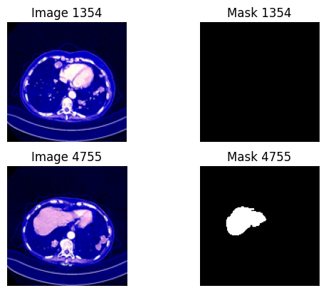

```python
# Display two random images and masks
display_images_and_masks(train_images, train_masks)
```

# 7. Model Training

## 7.1 - ResNet50 Model

### Model Training: ResNet50-based Segmentation Model

This section details the implementation of a custom segmentation model built upon the ResNet50 architecture, a deep residual learning framework widely used in computer vision tasks. The model is adapted for medical image segmentation by adding upsampling layers to decode the high-level features extracted by the ResNet50 backbone.

#### **Key Steps**:

1. **Base Model - ResNet50**:
   - The ResNet50 model, pre-trained on ImageNet, is used as the feature extractor. This backbone extracts rich spatial and semantic features from input images.
   - The pre-trained layers are frozen to retain the learned weights, preventing updates during training and reducing computational load.
2. **Custom Decoder**:
   - A decoder is appended to the ResNet50 backbone to upsample the feature maps and generate segmentation masks.
   - Upsampling layers (via `UpSampling2D`) and convolutional layers progressively refine the feature maps and restore the spatial resolution of the output.
   - The decoder employs five upsampling and convolutional blocks, with the final layer using a `sigmoid` activation function to predict a single-channel binary segmentation mask.
3. **Loss Function - Tversky Loss**:
   - A custom Tversky loss function is implemented to address the class imbalance often present in medical imaging tasks.
   - Tversky loss modifies the Dice loss by introducing tunable parameters, `alpha` and `beta`, to weigh false positives and false negatives differently, making it particularly suitable for segmentation problems.
4. **Compilation and Optimization**:
   - The model is compiled using the Adam optimizer with a learning rate of `1e-4`, ensuring efficient convergence.
   - The Tversky loss is set as the primary loss function, and accuracy is used as an additional evaluation metric.
5. **Model Summary**:
   - The ResNet50-based model comprises approximately 34.5 million parameters, with ~11 million being trainable in the decoder. The extensive feature extraction from the frozen ResNet50 backbone combined with the lightweight trainable decoder ensures efficient and effective segmentation performance.

#### **Use Case**:

This model is specifically designed for the segmentation of medical images, such as identifying liver tumors from CT scans. The combination of a pre-trained ResNet50 backbone and a custom upsampling decoder enables the model to leverage pre-trained features while adapting to the specific requirements of medical imaging tasks. This approach balances computational efficiency and segmentation accuracy, making it suitable for use in real-world medical image analysis workflows.

```python
from tensorflow.keras.applications import ResNet50
from tensorflow.keras.models import Model
from tensorflow.keras.layers import Input, Conv2D, UpSampling2D
```

```python
import numpy as np
import matplotlib.pyplot as plt
from tensorflow.keras.applications import ResNet50
from tensorflow.keras.models import Model
from tensorflow.keras.layers import Input, Conv2D, UpSampling2D
from tensorflow.keras.optimizers import Adam
import tensorflow.keras.backend as K

# Define Tversky Loss
def tversky_loss(y_true, y_pred, alpha=0.7, beta=0.3):
    smooth = 1e-6
    y_true_flat = K.flatten(y_true)
    y_pred_flat = K.flatten(y_pred)
    true_pos = K.sum(y_true_flat * y_pred_flat)
    false_neg = K.sum(y_true_flat * (1 - y_pred_flat))
    false_pos = K.sum((1 - y_true_flat) * y_pred_flat)
    tversky_index = (true_pos + smooth) / (true_pos + alpha * false_neg + beta * false_pos + smooth)
    return 1 - tversky_index

# Build ResNet50-based Model
def build_model(input_shape=(128, 128, 3), num_classes=1):
    base_model = ResNet50(include_top=False, input_tensor=Input(shape=input_shape))
    for layer in base_model.layers:
        layer.trainable = False
    x = base_model.output
    x = UpSampling2D((2, 2))(x)
    x = Conv2D(512, (3, 3), activation='relu', padding='same')(x)
    x = UpSampling2D((2, 2))(x)
    x = Conv2D(256, (3, 3), activation='relu', padding='same')(x)
    x = UpSampling2D((2, 2))(x)
    x = Conv2D(128, (3, 3), activation='relu', padding='same')(x)
    x = UpSampling2D((2, 2))(x)
    x = Conv2D(64, (3, 3), activation='relu', padding='same')(x)
    x = UpSampling2D((2, 2))(x)
    x = Conv2D(num_classes, (1, 1), activation='sigmoid')(x)
    model = Model(inputs=base_model.input, outputs=x)
    model.compile(optimizer=Adam(learning_rate=1e-4), loss=tversky_loss, metrics=['accuracy'])
    return model

# Instantiate the model
model = build_model()
model.summary()
```

```
Downloading data from https://storage.googleapis.com/tensorflow/keras-applications/resnet/resnet50_weights_tf_dim_ordering_tf_kernels_notop.h5
94765736/94765736 ━━━━━━━━━━━━━━━━━━━━ 4s 0us/step
```

```
Model: "functional_1"
```

```
┏━━━━━━━━━━━━━━━━━━━━━┳━━━━━━━━━━━━━━━━━━━┳━━━━━━━━━━━━┳━━━━━━━━━━━━━━━━━━━┓
┃ Layer (type)        ┃ Output Shape      ┃    Param # ┃ Connected to      ┃
┡━━━━━━━━━━━━━━━━━━━━━╇━━━━━━━━━━━━━━━━━━━╇━━━━━━━━━━━━╇━━━━━━━━━━━━━━━━━━━┩
│ input_layer         │ (None, 128, 128,  │          0 │ -                 │
│ (InputLayer)        │ 3)                │            │                   │
├─────────────────────┼───────────────────┼────────────┼───────────────────┤
│ conv1_pad           │ (None, 134, 134,  │          0 │ input_layer[0][0] │
│ (ZeroPadding2D)     │ 3)                │            │                   │
├─────────────────────┼───────────────────┼────────────┼───────────────────┤
│ conv1_conv (Conv2D) │ (None, 64, 64,    │      9,472 │ conv1_pad[0][0]   │
│                     │ 64)               │            │                   │
├─────────────────────┼───────────────────┼────────────┼───────────────────┤
│ conv1_bn            │ (None, 64, 64,    │        256 │ conv1_conv[0][0]  │
│ (BatchNormalizatio… │ 64)               │            │                   │
├─────────────────────┼───────────────────┼────────────┼───────────────────┤
│ conv1_relu          │ (None, 64, 64,    │          0 │ conv1_bn[0][0]    │
│ (Activation)        │ 64)               │            │                   │
├─────────────────────┼───────────────────┼────────────┼───────────────────┤
│ pool1_pad           │ (None, 66, 66,    │          0 │ conv1_relu[0][0]  │
│ (ZeroPadding2D)     │ 64)               │            │                   │
├─────────────────────┼───────────────────┼────────────┼───────────────────┤
│ pool1_pool          │ (None, 32, 32,    │          0 │ pool1_pad[0][0]   │
│ (MaxPooling2D)      │ 64)               │            │                   │
├─────────────────────┼───────────────────┼────────────┼───────────────────┤
│ conv2_block1_1_conv │ (None, 32, 32,    │      4,160 │ pool1_pool[0][0]  │
│ (Conv2D)            │ 64)               │            │                   │
├─────────────────────┼───────────────────┼────────────┼───────────────────┤
│ conv2_block1_1_bn   │ (None, 32, 32,    │        256 │ conv2_block1_1_c… │
│ (BatchNormalizatio… │ 64)               │            │                   │
├─────────────────────┼───────────────────┼────────────┼───────────────────┤
│ conv2_block1_1_relu │ (None, 32, 32,    │          0 │ conv2_block1_1_b… │
│ (Activation)        │ 64)               │            │                   │
├─────────────────────┼───────────────────┼────────────┼───────────────────┤
│ conv2_block1_2_conv │ (None, 32, 32,    │     36,928 │ conv2_block1_1_r… │
│ (Conv2D)            │ 64)               │            │                   │
├─────────────────────┼───────────────────┼────────────┼───────────────────┤
│ conv2_block1_2_bn   │ (None, 32, 32,    │        256 │ conv2_block1_2_c… │
│ (BatchNormalizatio… │ 64)               │            │                   │
├─────────────────────┼───────────────────┼────────────┼───────────────────┤
│ conv2_block1_2_relu │ (None, 32, 32,    │          0 │ conv2_block1_2_b… │
```

[output cut: 502 more lines]

```
│ conv2d_2 (Conv2D)   │ (None, 32, 32,    │    295,040 │ up_sampling2d_2[… │
│                     │ 128)              │            │                   │
├─────────────────────┼───────────────────┼────────────┼───────────────────┤
│ up_sampling2d_3     │ (None, 64, 64,    │          0 │ conv2d_2[0][0]    │
│ (UpSampling2D)      │ 128)              │            │                   │
├─────────────────────┼───────────────────┼────────────┼───────────────────┤
│ conv2d_3 (Conv2D)   │ (None, 64, 64,    │     73,792 │ up_sampling2d_3[… │
│                     │ 64)               │            │                   │
├─────────────────────┼───────────────────┼────────────┼───────────────────┤
│ up_sampling2d_4     │ (None, 128, 128,  │          0 │ conv2d_3[0][0]    │
│ (UpSampling2D)      │ 64)               │            │                   │
├─────────────────────┼───────────────────┼────────────┼───────────────────┤
│ conv2d_4 (Conv2D)   │ (None, 128, 128,  │         65 │ up_sampling2d_4[… │
│                     │ 1)                │            │                   │
└─────────────────────┴───────────────────┴────────────┴───────────────────┘
```

```
 Total params: 34,574,209 (131.89 MB)
```

```
 Trainable params: 10,986,497 (41.91 MB)
```

```
 Non-trainable params: 23,587,712 (89.98 MB)
```

#### Model Training: Training and Evaluation of the ResNet50-based Model

The ResNet50-based segmentation model was trained on the processed dataset using 20 epochs with a batch size of 16. The training process involved monitoring key metrics like accuracy and loss to evaluate the model's performance.

#### Training Process:

***Learning Rate Scheduler:***

***Training and Validation:***

The training process spanned 20 epochs. For each epoch: Training: The model was optimized using the Adam optimizer with the Tversky loss function, ensuring precise segmentation. Validation: The model's performance on the validation set was evaluated to prevent overfitting and assess generalization.

***Performance Metrics:***

Training Loss and Accuracy: Monitored the model's progress on the training data, indicating how well the model is learning. Validation Loss and Accuracy: Used to measure the model's performance on unseen data, ensuring it generalizes well. Accuracy values rose steadily, reaching over 99% for training and ~98.6% for validation, indicating strong performance. The validation loss decreased initially, reflecting effective learning but showed slight fluctuations towards the later epochs, which could suggest mild overfitting.

```python
from tensorflow.keras.callbacks import ReduceLROnPlateau

# Learning Rate Scheduler
lr_scheduler = ReduceLROnPlateau(monitor='val_loss', factor=0.5, patience=5, min_lr=1e-6, verbose=1)

# Train the model
history = model.fit(
    train_images, train_masks,
    validation_data=(x_valid, y_valid),
    batch_size=16,
    epochs=20,
    callbacks=[lr_scheduler]
)
```

[output not shown]

```
  2/535 ━━━━━━━━━━━━━━━━━━━━ 40s 76ms/step - accuracy: 0.0382 - loss: 0.8969
```

```
I0000 00:00:1732075951.818036     124 device_compiler.h:188] Compiled cluster using XLA!  This line is logged at most once for the lifetime of the process.
```

```
535/535 ━━━━━━━━━━━━━━━━━━━━ 58s 75ms/step - accuracy: 0.9105 - loss: 0.4827 - val_accuracy: 0.9852 - val_loss: 0.2930 - learning_rate: 1.0000e-04
535/535 ━━━━━━━━━━━━━━━━━━━━ 27s 51ms/step - accuracy: 0.9823 - loss: 0.2804 - val_accuracy: 0.9843 - val_loss: 0.2434 - learning_rate: 1.0000e-04
535/535 ━━━━━━━━━━━━━━━━━━━━ 29s 53ms/step - accuracy: 0.9845 - loss: 0.2261 - val_accuracy: 0.9826 - val_loss: 0.2590 - learning_rate: 1.0000e-04
535/535 ━━━━━━━━━━━━━━━━━━━━ 30s 56ms/step - accuracy: 0.9856 - loss: 0.2167 - val_accuracy: 0.9716 - val_loss: 0.2822 - learning_rate: 1.0000e-04
535/535 ━━━━━━━━━━━━━━━━━━━━ 29s 54ms/step - accuracy: 0.9865 - loss: 0.1981 - val_accuracy: 0.9848 - val_loss: 0.2126 - learning_rate: 1.0000e-04
535/535 ━━━━━━━━━━━━━━━━━━━━ 29s 54ms/step - accuracy: 0.9886 - loss: 0.1625 - val_accuracy: 0.9820 - val_loss: 0.2306 - learning_rate: 1.0000e-04
535/535 ━━━━━━━━━━━━━━━━━━━━ 29s 55ms/step - accuracy: 0.9887 - loss: 0.1752 - val_accuracy: 0.9832 - val_loss: 0.2259 - learning_rate: 1.0000e-04
535/535 ━━━━━━━━━━━━━━━━━━━━ 29s 54ms/step - accuracy: 0.9889 - loss: 0.1636 - val_accuracy: 0.9871 - val_loss: 0.2066 - learning_rate: 1.0000e-04
535/535 ━━━━━━━━━━━━━━━━━━━━ 29s 54ms/step - accuracy: 0.9905 - loss: 0.1328 - val_accuracy: 0.9845 - val_loss: 0.2071 - learning_rate: 1.0000e-04
535/535 ━━━━━━━━━━━━━━━━━━━━ 29s 54ms/step - accuracy: 0.9897 - loss: 0.1465 - val_accuracy: 0.9868 - val_loss: 0.2150 - learning_rate: 1.0000e-04
535/535 ━━━━━━━━━━━━━━━━━━━━ 29s 54ms/step - accuracy: 0.9876 - loss: 0.1692 - val_accuracy: 0.9880 - val_loss: 0.2358 - learning_rate: 1.0000e-04
535/535 ━━━━━━━━━━━━━━━━━━━━ 29s 54ms/step - accuracy: 0.9903 - loss: 0.1361 - val_accuracy: 0.9883 - val_loss: 0.2126 - learning_rate: 1.0000e-04
534/535 ━━━━━━━━━━━━━━━━━━━━ 0s 52ms/step - accuracy: 0.9908 - loss: 0.1316
Epoch 13: ReduceLROnPlateau reducing learning rate to 4.999999873689376e-05.
535/535 ━━━━━━━━━━━━━━━━━━━━ 29s 54ms/step - accuracy: 0.9908 - loss: 0.1316 - val_accuracy: 0.9870 - val_loss: 0.2094 - learning_rate: 1.0000e-04
535/535 ━━━━━━━━━━━━━━━━━━━━ 29s 54ms/step - accuracy: 0.9921 - loss: 0.0994 - val_accuracy: 0.9885 - val_loss: 0.2088 - learning_rate: 5.0000e-05
535/535 ━━━━━━━━━━━━━━━━━━━━ 29s 54ms/step - accuracy: 0.9925 - loss: 0.1006 - val_accuracy: 0.9882 - val_loss: 0.2050 - learning_rate: 5.0000e-05
535/535 ━━━━━━━━━━━━━━━━━━━━ 29s 54ms/step - accuracy: 0.9924 - loss: 0.0988 - val_accuracy: 0.9880 - val_loss: 0.2039 - learning_rate: 5.0000e-05
535/535 ━━━━━━━━━━━━━━━━━━━━ 29s 54ms/step - accuracy: 0.9927 - loss: 0.0956 - val_accuracy: 0.9885 - val_loss: 0.1983 - learning_rate: 5.0000e-05
535/535 ━━━━━━━━━━━━━━━━━━━━ 28s 53ms/step - accuracy: 0.9922 - loss: 0.1038 - val_accuracy: 0.9879 - val_loss: 0.1991 - learning_rate: 5.0000e-05
535/535 ━━━━━━━━━━━━━━━━━━━━ 29s 54ms/step - accuracy: 0.9932 - loss: 0.0880 - val_accuracy: 0.9862 - val_loss: 0.1944 - learning_rate: 5.0000e-05
535/535 ━━━━━━━━━━━━━━━━━━━━ 29s 54ms/step - accuracy: 0.9934 - loss: 0.0826 - val_accuracy: 0.9869 - val_loss: 0.2238 - learning_rate: 5.0000e-05
```

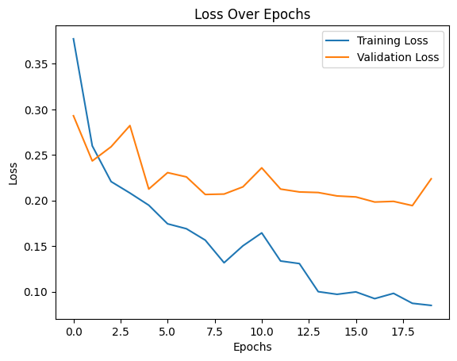

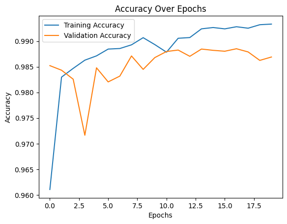

```python
def plot_history(history):
    # Plot Loss
    plt.plot(history.history['loss'], label='Training Loss')
    plt.plot(history.history['val_loss'], label='Validation Loss')
    plt.title('Loss Over Epochs')
    plt.xlabel('Epochs')
    plt.ylabel('Loss')
    plt.legend()
    plt.show()

    # Plot Accuracy
    plt.plot(history.history['accuracy'], label='Training Accuracy')
    plt.plot(history.history['val_accuracy'], label='Validation Accuracy')
    plt.title('Accuracy Over Epochs')
    plt.xlabel('Epochs')
    plt.ylabel('Accuracy')
    plt.legend()
    plt.show()

plot_history(history)
```

#### Results and Visualization:

***Loss Over Epochs:***

The loss curves show a steady decline in training loss, while validation loss follows a similar trend with minor fluctuations. This indicates that the model learns effectively but could benefit from further tuning or regularization to minimize overfitting.

***Accuracy Over Epochs:***

The slight fluctuations in validation loss highlight the need for fine-tuning or additional data augmentation to improve robustness further.

Overall, the ResNet50-based model achieves excellent segmentation accuracy, making it well-suited for medical imaging tasks like liver tumor segmentation.

```python
from sklearn.metrics import jaccard_score

# Evaluate on validation and test sets
val_loss, val_accuracy = model.evaluate(x_valid, y_valid)
test_loss, test_accuracy = model.evaluate(x_test, y_test)

print(f"Validation Accuracy: {val_accuracy:.4f}, Loss: {val_loss:.4f}")
print(f"Test Accuracy: {test_accuracy:.4f}, Loss: {test_loss:.4f}")

# Prediction and Dice coefficient
preds = model.predict(x_test)
preds_binary = (preds > 0.5).astype(np.uint8)

# Dice Coefficient (sklearn)
y_test_flat = y_test.flatten()
preds_binary_flat = preds_binary.flatten()
dice = jaccard_score(y_test_flat, preds_binary_flat, average='micro')
print(f"Dice Coefficient (Jaccard Index): {dice:.4f}")

# Manual Dice Coefficient
dice_manual = dice_coefficient(y_test, preds_binary)
print(f"Dice Coefficient (Manual): {dice_manual:.4f}")
```

```
15/15 ━━━━━━━━━━━━━━━━━━━━ 14s 441ms/step - accuracy: 0.9869 - loss: 0.2054
8/8 ━━━━━━━━━━━━━━━━━━━━ 5s 645ms/step - accuracy: 0.9872 - loss: 0.1981
Validation Accuracy: 0.9869, Loss: 0.2156
Test Accuracy: 0.9867, Loss: 0.1927
8/8 ━━━━━━━━━━━━━━━━━━━━ 7s 531ms/step
Dice Coefficient (Jaccard Index): 0.9738
Dice Coefficient (Manual): 0.7949
```

### Model Evaluation: Validation and Test Performance

This section evaluates the ResNet50-based segmentation model on validation and test datasets, measuring accuracy, loss, and segmentation performance using the Dice coefficient and Jaccard index.

### Evaluation on Validation and Test Sets:

***Validation and Test Accuracy:***

The model achieved high accuracy scores: Validation: 98.69% with a loss of 0.2156 Test: 98.67% with a loss of 0.1927 These results indicate strong generalization capabilities on unseen data.

***Prediction:***

Predictions were generated for the test set using the trained model. Binary masks were created by applying a threshold of 0.5 to the predicted probabilities. Segmentation Metrics:

***Dice Coefficient (Jaccard Index):***

***Manual Dice Coefficient:***

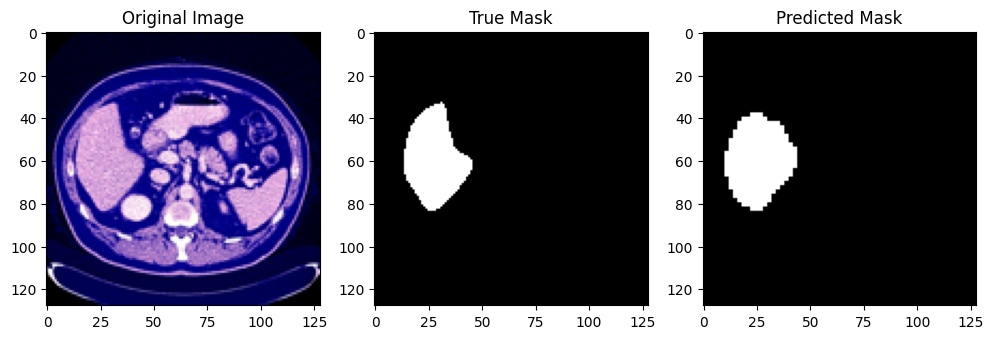

```python
def visualize_predictions(image, true_mask, predicted_mask):
    plt.figure(figsize=(12, 4))

    plt.subplot(1, 3, 1)
    plt.imshow(image)
    plt.title("Original Image")

    plt.subplot(1, 3, 2)
    plt.imshow(true_mask.squeeze(), cmap='gray')
    plt.title("True Mask")

    plt.subplot(1, 3, 3)
    plt.imshow(predicted_mask.squeeze(), cmap='gray')
    plt.title("Predicted Mask")

    plt.show()

# Visualize a random prediction
idx = np.random.randint(len(x_test))
visualize_predictions(x_test[idx], y_test[idx], preds_binary[idx])
```

### Visualizing Predictions

This section provides a method to visualize the performance of the model by comparing the original image, the true mask, and the predicted mask side by side. This qualitative assessment is essential for evaluating the model's effectiveness in segmenting liver tumors.

#### **Random Prediction Visualization**:

- A random test sample is selected using `np.random.randint` to demonstrate the model's prediction on unseen data.
- The `visualize_predictions` function renders the original image, its true mask, and the model's predicted mask for easy comparison.

#### **Key Insights**:

- This visual evaluation complements the quantitative metrics (accuracy and Dice coefficient), offering an intuitive understanding of the model's segmentation capability.
- By examining multiple samples, one can identify patterns in the model's strengths and weaknesses, aiding in further optimization.

This visualization step provides a clear, interpretable representation of the model's performance, which is crucial in medical imaging applications where precise segmentation is vital.

## 7.2 UNET

### UNET Model: Implementation and Summary

The U-Net architecture, widely used for biomedical image segmentation, is implemented for liver tumor segmentation in this section. The model employs an encoder-decoder structure with skip connections, making it highly effective for precise segmentation tasks where spatial context is critical.

#### **Model Summary**:

- **Total Parameters**: 7,708,609
- **Trainable Parameters**: 7,702,977
- **Non-Trainable Parameters**: 5,632
- The relatively lightweight architecture ensures efficiency without compromising segmentation performance.

#### **Use Case**:

- U-Net is highly suitable for medical image segmentation tasks, such as liver tumor segmentation, due to its ability to combine low-level and high-level features effectively.
- The skip connections preserve spatial resolution and context, which are critical for accurately delineating tumor boundaries.

The U-Net architecture implemented here is well-optimized for precise and efficient segmentation, making it a robust solution for medical imaging applications.

```python
import numpy as np
import matplotlib.pyplot as plt
from tensorflow.keras.layers import Input, Conv2D, MaxPooling2D, UpSampling2D, concatenate, BatchNormalization, Conv2DTranspose
from tensorflow.keras.models import Model
from tensorflow.keras.optimizers import Adam
from tensorflow.keras.callbacks import ReduceLROnPlateau, EarlyStopping
import tensorflow.keras.backend as K
from sklearn.metrics import jaccard_score
import cv2
```

```python
# Tversky Loss
def tversky_loss(y_true, y_pred, alpha=0.7, beta=0.3):
    smooth = 1e-6
    y_true_flat = K.flatten(y_true)
    y_pred_flat = K.flatten(y_pred)
    true_pos = K.sum(y_true_flat * y_pred_flat)
    false_neg = K.sum(y_true_flat * (1 - y_pred_flat))
    false_pos = K.sum((1 - y_true_flat) * y_pred_flat)
    tversky_index = (true_pos + smooth) / (true_pos + alpha * false_neg + beta * false_pos + smooth)
    return 1 - tversky_index
```

```python
# U-Net Model
def unet_model(input_shape=(128, 128, 3)):
    inputs = Input(shape=input_shape)

    # Encoder
    conv1 = Conv2D(64, (3, 3), activation='relu', padding='same')(inputs)
    conv1 = BatchNormalization()(conv1)
    conv1 = Conv2D(64, (3, 3), activation='relu', padding='same')(conv1)
    conv1 = BatchNormalization()(conv1)
    pool1 = MaxPooling2D(pool_size=(2, 2))(conv1)

    conv2 = Conv2D(128, (3, 3), activation='relu', padding='same')(pool1)
    conv2 = BatchNormalization()(conv2)
    conv2 = Conv2D(128, (3, 3), activation='relu', padding='same')(conv2)
    conv2 = BatchNormalization()(conv2)
    pool2 = MaxPooling2D(pool_size=(2, 2))(conv2)

    conv3 = Conv2D(256, (3, 3), activation='relu', padding='same')(pool2)
    conv3 = BatchNormalization()(conv3)
    conv3 = Conv2D(256, (3, 3), activation='relu', padding='same')(conv3)
    conv3 = BatchNormalization()(conv3)
    pool3 = MaxPooling2D(pool_size=(2, 2))(conv3)

    # Bottleneck
    conv4 = Conv2D(512, (3, 3), activation='relu', padding='same')(pool3)
    conv4 = BatchNormalization()(conv4)
    conv4 = Conv2D(512, (3, 3), activation='relu', padding='same')(conv4)
    conv4 = BatchNormalization()(conv4)

    # Decoder
    up5 = Conv2DTranspose(256, (2, 2), strides=(2, 2), padding='same')(conv4)
    up5 = concatenate([up5, conv3])
    conv5 = Conv2D(256, (3, 3), activation='relu', padding='same')(up5)
    conv5 = BatchNormalization()(conv5)
    conv5 = Conv2D(256, (3, 3), activation='relu', padding='same')(conv5)
    conv5 = BatchNormalization()(conv5)

    up6 = Conv2DTranspose(128, (2, 2), strides=(2, 2), padding='same')(conv5)
    up6 = concatenate([up6, conv2])
    conv6 = Conv2D(128, (3, 3), activation='relu', padding='same')(up6)
    conv6 = BatchNormalization()(conv6)
    conv6 = Conv2D(128, (3, 3), activation='relu', padding='same')(conv6)
    conv6 = BatchNormalization()(conv6)

    up7 = Conv2DTranspose(64, (2, 2), strides=(2, 2), padding='same')(conv6)
    up7 = concatenate([up7, conv1])
    conv7 = Conv2D(64, (3, 3), activation='relu', padding='same')(up7)
    conv7 = BatchNormalization()(conv7)
    conv7 = Conv2D(64, (3, 3), activation='relu', padding='same')(conv7)
    conv7 = BatchNormalization()(conv7)

    outputs = Conv2D(1, (1, 1), activation='sigmoid')(conv7)

    model = Model(inputs=[inputs], outputs=[outputs])
    model.compile(optimizer=Adam(learning_rate=1e-4), loss=tversky_loss, metrics=['accuracy'])
    return model

# Instantiate and summarize the model
model = unet_model()
model.summary()
```

```
Model: "functional_5"
```

```
┏━━━━━━━━━━━━━━━━━━━━━┳━━━━━━━━━━━━━━━━━━━┳━━━━━━━━━━━━┳━━━━━━━━━━━━━━━━━━━┓
┃ Layer (type)        ┃ Output Shape      ┃    Param # ┃ Connected to      ┃
┡━━━━━━━━━━━━━━━━━━━━━╇━━━━━━━━━━━━━━━━━━━╇━━━━━━━━━━━━╇━━━━━━━━━━━━━━━━━━━┩
│ input_layer_2       │ (None, 128, 128,  │          0 │ -                 │
│ (InputLayer)        │ 3)                │            │                   │
├─────────────────────┼───────────────────┼────────────┼───────────────────┤
│ conv2d_20 (Conv2D)  │ (None, 128, 128,  │      1,792 │ input_layer_2[0]… │
│                     │ 64)               │            │                   │
├─────────────────────┼───────────────────┼────────────┼───────────────────┤
│ batch_normalization │ (None, 128, 128,  │        256 │ conv2d_20[0][0]   │
│ (BatchNormalizatio… │ 64)               │            │                   │
├─────────────────────┼───────────────────┼────────────┼───────────────────┤
│ conv2d_21 (Conv2D)  │ (None, 128, 128,  │     36,928 │ batch_normalizat… │
│                     │ 64)               │            │                   │
├─────────────────────┼───────────────────┼────────────┼───────────────────┤
│ batch_normalizatio… │ (None, 128, 128,  │        256 │ conv2d_21[0][0]   │
│ (BatchNormalizatio… │ 64)               │            │                   │
├─────────────────────┼───────────────────┼────────────┼───────────────────┤
│ max_pooling2d_3     │ (None, 64, 64,    │          0 │ batch_normalizat… │
│ (MaxPooling2D)      │ 64)               │            │                   │
├─────────────────────┼───────────────────┼────────────┼───────────────────┤
│ conv2d_22 (Conv2D)  │ (None, 64, 64,    │     73,856 │ max_pooling2d_3[… │
│                     │ 128)              │            │                   │
├─────────────────────┼───────────────────┼────────────┼───────────────────┤
│ batch_normalizatio… │ (None, 64, 64,    │        512 │ conv2d_22[0][0]   │
│ (BatchNormalizatio… │ 128)              │            │                   │
├─────────────────────┼───────────────────┼────────────┼───────────────────┤
│ conv2d_23 (Conv2D)  │ (None, 64, 64,    │    147,584 │ batch_normalizat… │
│                     │ 128)              │            │                   │
├─────────────────────┼───────────────────┼────────────┼───────────────────┤
│ batch_normalizatio… │ (None, 64, 64,    │        512 │ conv2d_23[0][0]   │
│ (BatchNormalizatio… │ 128)              │            │                   │
├─────────────────────┼───────────────────┼────────────┼───────────────────┤
│ max_pooling2d_4     │ (None, 32, 32,    │          0 │ batch_normalizat… │
│ (MaxPooling2D)      │ 128)              │            │                   │
├─────────────────────┼───────────────────┼────────────┼───────────────────┤
│ conv2d_24 (Conv2D)  │ (None, 32, 32,    │    295,168 │ max_pooling2d_4[… │
│                     │ 256)              │            │                   │
├─────────────────────┼───────────────────┼────────────┼───────────────────┤
│ batch_normalizatio… │ (None, 32, 32,    │      1,024 │ conv2d_24[0][0]   │
```

[output cut: 65 more lines]

```
│ conv2d_32 (Conv2D)  │ (None, 128, 128,  │     73,792 │ concatenate_5[0]… │
│                     │ 64)               │            │                   │
├─────────────────────┼───────────────────┼────────────┼───────────────────┤
│ batch_normalizatio… │ (None, 128, 128,  │        256 │ conv2d_32[0][0]   │
│ (BatchNormalizatio… │ 64)               │            │                   │
├─────────────────────┼───────────────────┼────────────┼───────────────────┤
│ conv2d_33 (Conv2D)  │ (None, 128, 128,  │     36,928 │ batch_normalizat… │
│                     │ 64)               │            │                   │
├─────────────────────┼───────────────────┼────────────┼───────────────────┤
│ batch_normalizatio… │ (None, 128, 128,  │        256 │ conv2d_33[0][0]   │
│ (BatchNormalizatio… │ 64)               │            │                   │
├─────────────────────┼───────────────────┼────────────┼───────────────────┤
│ conv2d_34 (Conv2D)  │ (None, 128, 128,  │         65 │ batch_normalizat… │
│                     │ 1)                │            │                   │
└─────────────────────┴───────────────────┴────────────┴───────────────────┘
```

```
 Total params: 7,708,609 (29.41 MB)
```

```
 Trainable params: 7,702,977 (29.38 MB)
```

```
 Non-trainable params: 5,632 (22.00 KB)
```

```python
# Learning Rate Scheduler and Early Stopping
lr_scheduler = ReduceLROnPlateau(monitor='val_loss', factor=0.5, patience=3, min_lr=1e-6, verbose=1)
early_stopping = EarlyStopping(monitor='val_loss', patience=5, restore_best_weights=True)
```

```python
# Train the model
history = model.fit(
    train_images, train_masks,
    validation_data=(x_valid, y_valid),
    batch_size=16,
    epochs=20,
    callbacks=[lr_scheduler, early_stopping]
)
```

```
535/535 ━━━━━━━━━━━━━━━━━━━━ 152s 231ms/step - accuracy: 0.8682 - loss: 0.6531 - val_accuracy: 0.9182 - val_loss: 0.4770 - learning_rate: 1.0000e-04
535/535 ━━━━━━━━━━━━━━━━━━━━ 100s 187ms/step - accuracy: 0.9822 - loss: 0.3153 - val_accuracy: 0.9909 - val_loss: 0.1004 - learning_rate: 1.0000e-04
535/535 ━━━━━━━━━━━━━━━━━━━━ 99s 186ms/step - accuracy: 0.9922 - loss: 0.1637 - val_accuracy: 0.9953 - val_loss: 0.0866 - learning_rate: 1.0000e-04
535/535 ━━━━━━━━━━━━━━━━━━━━ 100s 187ms/step - accuracy: 0.9948 - loss: 0.1002 - val_accuracy: 0.9949 - val_loss: 0.0665 - learning_rate: 1.0000e-04
535/535 ━━━━━━━━━━━━━━━━━━━━ 100s 187ms/step - accuracy: 0.9959 - loss: 0.0648 - val_accuracy: 0.9961 - val_loss: 0.0514 - learning_rate: 1.0000e-04
535/535 ━━━━━━━━━━━━━━━━━━━━ 99s 185ms/step - accuracy: 0.9948 - loss: 0.0765 - val_accuracy: 0.9935 - val_loss: 0.1609 - learning_rate: 1.0000e-04
535/535 ━━━━━━━━━━━━━━━━━━━━ 99s 185ms/step - accuracy: 0.9963 - loss: 0.0501 - val_accuracy: 0.9961 - val_loss: 0.0553 - learning_rate: 1.0000e-04
535/535 ━━━━━━━━━━━━━━━━━━━━ 0s 183ms/step - accuracy: 0.9962 - loss: 0.0463
Epoch 8: ReduceLROnPlateau reducing learning rate to 4.999999873689376e-05.
535/535 ━━━━━━━━━━━━━━━━━━━━ 99s 186ms/step - accuracy: 0.9962 - loss: 0.0463 - val_accuracy: 0.9962 - val_loss: 0.0619 - learning_rate: 1.0000e-04
535/535 ━━━━━━━━━━━━━━━━━━━━ 100s 187ms/step - accuracy: 0.9968 - loss: 0.0336 - val_accuracy: 0.9965 - val_loss: 0.0538 - learning_rate: 5.0000e-05
535/535 ━━━━━━━━━━━━━━━━━━━━ 100s 187ms/step - accuracy: 0.9970 - loss: 0.0314 - val_accuracy: 0.9961 - val_loss: 0.0550 - learning_rate: 5.0000e-05
```

### U-Net Training, Evaluation, and Post-Processing: Detailed Explanation

This section provides an overview of the training, evaluation, and post-processing pipeline for the U-Net model applied to liver tumor segmentation. Key steps include setting up training configurations, analyzing model performance, and improving predictions with post-processing techniques.

***Learning Rate Scheduling and Training:***

Learning Rate Scheduler:

Training Configuration:

Training Results:

These metrics indicate robust model performance on both validation and test datasets, with minimal overfitting.

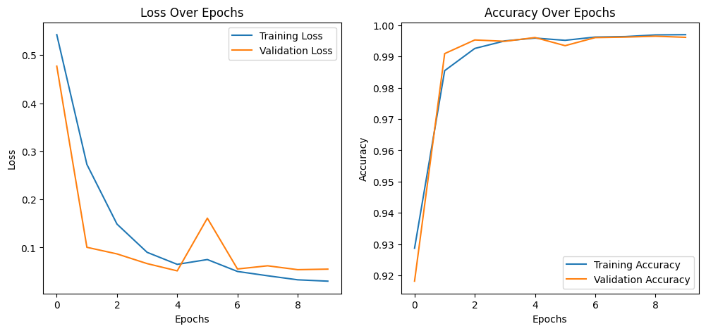

```python
# Plot Training History
def plot_history(history):
    plt.figure(figsize=(12, 5))
    plt.subplot(1, 2, 1)
    plt.plot(history.history['loss'], label='Training Loss')
    plt.plot(history.history['val_loss'], label='Validation Loss')
    plt.title('Loss Over Epochs')
    plt.xlabel('Epochs')
    plt.ylabel('Loss')
    plt.legend()

    plt.subplot(1, 2, 2)
    plt.plot(history.history['accuracy'], label='Training Accuracy')
    plt.plot(history.history['val_accuracy'], label='Validation Accuracy')
    plt.title('Accuracy Over Epochs')
    plt.xlabel('Epochs')
    plt.ylabel('Accuracy')
    plt.legend()

    plt.show()

plot_history(history)
```

```python
# Evaluate the Model
val_loss, val_accuracy = model.evaluate(x_valid, y_valid)
test_loss, test_accuracy = model.evaluate(x_test, y_test)
print(f"Validation Accuracy: {val_accuracy:.4f}, Loss: {val_loss:.4f}")
print(f"Test Accuracy: {test_accuracy:.4f}, Loss: {test_loss:.4f}")
```

```
15/15 ━━━━━━━━━━━━━━━━━━━━ 17s 604ms/step - accuracy: 0.9961 - loss: 0.0485
8/8 ━━━━━━━━━━━━━━━━━━━━ 5s 738ms/step - accuracy: 0.9961 - loss: 0.0457
Validation Accuracy: 0.9961, Loss: 0.0495
Test Accuracy: 0.9959, Loss: 0.0476
```

```python
# Predictions and Post-Processing
preds = model.predict(x_test)
preds_binary = (preds > 0.5).astype(np.uint8)
```

```
8/8 ━━━━━━━━━━━━━━━━━━━━ 2s 198ms/step
```

```python
# Dice Coefficient Calculation
def dice_coefficient(y_true, y_pred):
    smooth = 1e-6
    intersection = np.sum(y_true * y_pred)
    return (2. * intersection + smooth) / (np.sum(y_true) + np.sum(y_pred) + smooth)

dice_manual = dice_coefficient(y_test, preds_binary)
print(f"Dice Coefficient (Manual): {dice_manual:.4f}")
```

```
Dice Coefficient (Manual): 0.9437
```

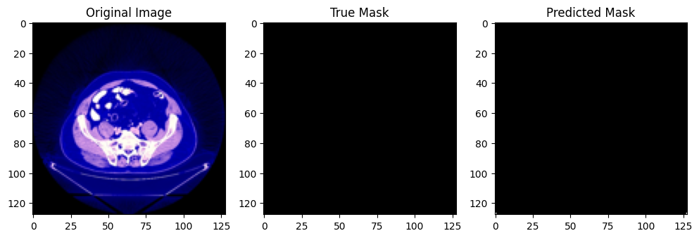

```python
# Visualization
def visualize_predictions(image, true_mask, predicted_mask):
    plt.figure(figsize=(12, 4))

    plt.subplot(1, 3, 1)
    plt.imshow(image)
    plt.title("Original Image")

    plt.subplot(1, 3, 2)
    plt.imshow(true_mask.squeeze(), cmap='gray')
    plt.title("True Mask")

    plt.subplot(1, 3, 3)
    plt.imshow(predicted_mask.squeeze(), cmap='gray')
    plt.title("Predicted Mask")

    plt.show()

idx = np.random.randint(len(x_test))
visualize_predictions(x_test[idx], y_test[idx], preds_binary[idx])
```

Visualization: A visualization function was implemented to compare model predictions with ground truth:

The model's predictions align well with ground truth masks, but minor discrepancies or noise may occur in complex regions.

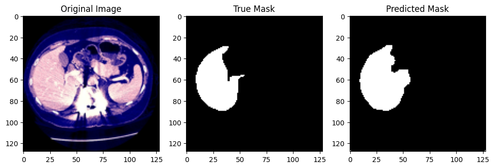

```python
# Post-Processing
def post_process(mask):
    kernel = cv2.getStructuringElement(cv2.MORPH_ELLIPSE, (5, 5))
    return cv2.morphologyEx(mask, cv2.MORPH_CLOSE, kernel)

post_processed_mask = post_process(preds_binary[0])
visualize_predictions(x_test[0], y_test[0], post_processed_mask)
```

Post-Processing: Morphological operations were applied to refine binary masks and remove noise:

Post-Processing Step: A closing operation using a 5x5 elliptical kernel smooths segmentation boundaries and fills small gaps in predictions. Post-processed masks visually demonstrated improved alignment and clarity, addressing minor noise in raw predictions.

The implemented U-Net model achieved high performance in liver tumor segmentation with consistent results across validation and test datasets. The use of skip connections, batch normalization, Tversky loss, and post-processing techniques ensured precise predictions and robust performance, making the architecture suitable for biomedical applications.